# Making a Baseball Game Prediction Model

Adam Alcala

#### PSTAT 131 Fall 2022

## Introduction

This project is designed to create a statistical model that predicts the chances of a Major League Baseball team winning a game. Since we are determining either winning or losing, this project will use a binary classification approach. For this project, the team I wanted to test this model with the Los Angeles Dodgers, because my family and I are huge fans of them. These are the packages required for the project

```r
library(tidymodels)
library(ISLR)
library(ISLR2)
library(tidyverse)
library(glmnet)
library(corrr)
library(corrplot)
library(ggplot2)
library(janitor)
library(dplyr)
library(stringr)
library(MASS)
library(knitr)
library(visdat)
library(readr)
library(parsnip)
library(discrim)
library(kknn)
library(ranger)
tidymodels_prefer()
```

### What is the MLB?

[figure not shown]

[figure not shown]

### What’s the purpose of the model?

For people not familiar with Baseball, or for those who do not completely immerse themselves in baseball analytics and theory crafting for future baseball games, it might be confusing how one baseball team will perform in the future. If you are rooting for a team, wouldn’t it be interesting to find out what it is that makes that team succeed? This is what I want to find out with this project. To see if there is a certain variable or situation that improve a team’s chances of winning a game. By the end of this project, I hope to give some insight for fans what indicates better chances of winning an game in the MLB.

### The Plan

In this project, I will be using the `'mlb-elo'` data set from fivethirtyeight.com. It contains data from every MLB game since 1871! The data set is available for download at [github](https://github.com/fivethirtyeight/data/tree/master/mlb-elo). To begin, the data will be cleaned and altered to fit better into the model later. After the data has been explored, I can use the different variables in the data set as ‘predictor variables’ which I will use to predict the chances of winning. Afterwards, I will split the data into training and test sets, create a recipe for the model, and use a 10-fold cross validation. For the models, Logistic Regression, Linear Discriminant Analysis, Lasso, K-nearest numbers, and Random forest models will be used to for the data. In the end, when all the models have been tested, I will use the most effective model on the testing data set to see how accurate my model is. If some of these terms seem a little confusing right now, we will go over each one as we go along.

## Exploratory Data Analysis

Once we load in the data, we need to check how it looks starting out. There can be variables that are in a form we cannot use yet, as well as some possible missing data. This is the point of cleaning and manipulating the data before we do anything else with it.

### Data cleaning and Manipulation

Lets begin by loading in the data set from the project github.

```r
mlb_elo <- read_csv("mlb_elo.csv")
head(mlb_elo)
```

```
## # A tibble: 6 × 26
##   date       season neutral playoff team1 team2 elo1_pre elo2_…¹ elo_p…² elo_p…³
##   <date>      <dbl>   <dbl> <chr>   <chr> <chr>    <dbl>   <dbl>   <dbl>   <dbl>
## 1 2022-11-05   2022       0 w       HOU   PHI      1600.   1546.   0.645   0.355
## 2 2022-11-03   2022       0 w       PHI   HOU      1548.   1598.   0.450   0.550
## 3 2022-11-02   2022       0 w       PHI   HOU      1552.   1594.   0.466   0.534
## 4 2022-11-01   2022       0 w       PHI   HOU      1546.   1600.   0.442   0.558
## 5 2022-10-29   2022       0 w       HOU   PHI      1598.   1548.   0.638   0.362
## 6 2022-10-28   2022       0 w       HOU   PHI      1601.   1545.   0.649   0.351
## # … with 16 more variables: elo1_post <dbl>, elo2_post <dbl>,
## #   rating1_pre <dbl>, rating2_pre <dbl>, pitcher1 <chr>, pitcher2 <chr>,
## #   pitcher1_rgs <dbl>, pitcher2_rgs <dbl>, pitcher1_adj <dbl>,
## #   pitcher2_adj <dbl>, rating_prob1 <dbl>, rating_prob2 <dbl>,
## #   rating1_post <dbl>, rating2_post <dbl>, score1 <dbl>, score2 <dbl>, and
## #   abbreviated variable names ¹elo2_pre, ²elo_prob1, ³elo_prob2
```

Additionally, we can check the dimensions of the data set as we load it in

```r
dim(mlb_elo)
```

```
## [1] 225897     26
```

It looks like the data loaded in just fine. There are 225,897 observations, with 26 different variables. However, this data includes games from all of the teams in the MLB. In order to get data for only the dodgers, we need to change the set a little bit.

```r
dodger_elo <- mlb_elo %>%
  filter(team1 == 'LAD' | team2 == 'LAD')
head(dodger_elo,10)
```

```
## # A tibble: 10 × 26
##    date       season neutral playoff team1 team2 elo1_…¹ elo2_…² elo_p…³ elo_p…⁴
##    <date>      <dbl>   <dbl> <chr>   <chr> <chr>   <dbl>   <dbl>   <dbl>   <dbl>
##  1 2022-10-15   2022       0 d       SDP   LAD     1535.   1605.   0.412   0.588
##  2 2022-10-14   2022       0 d       SDP   LAD     1532.   1608.   0.401   0.599
##  3 2022-10-12   2022       0 d       LAD   SDP     1612.   1527.   0.698   0.302
##  4 2022-10-11   2022       0 d       LAD   SDP     1611.   1529.   0.693   0.307
##  5 2022-10-05   2022       0 <NA>    LAD   COL     1610.   1456.   0.735   0.265
##  6 2022-10-04   2022       0 <NA>    LAD   COL     1614.   1452.   0.744   0.256
##  7 2022-10-03   2022       0 <NA>    LAD   COL     1616.   1450.   0.750   0.250
##  8 2022-10-02   2022       0 <NA>    LAD   COL     1621.   1445.   0.759   0.241
##  9 2022-10-01   2022       0 <NA>    LAD   COL     1620.   1446.   0.757   0.243
## 10 2022-09-30   2022       0 <NA>    LAD   COL     1618.   1448.   0.754   0.246
## # … with 16 more variables: elo1_post <dbl>, elo2_post <dbl>,
## #   rating1_pre <dbl>, rating2_pre <dbl>, pitcher1 <chr>, pitcher2 <chr>,
## #   pitcher1_rgs <dbl>, pitcher2_rgs <dbl>, pitcher1_adj <dbl>,
## #   pitcher2_adj <dbl>, rating_prob1 <dbl>, rating_prob2 <dbl>,
## #   rating1_post <dbl>, rating2_post <dbl>, score1 <dbl>, score2 <dbl>, and
## #   abbreviated variable names ¹elo1_pre, ²elo2_pre, ³elo_prob1, ⁴elo_prob2
```

Now the data set only includes games with the dodgers either in the home or away teams. How big is the data set now?

```r
dim(dodger_elo)
```

```
## [1] 21588    26
```

There’s now only 21,588 observations, which is still a very big data set. Let’s start checking for any inconsistent data. We’ll see if any data is missing first.

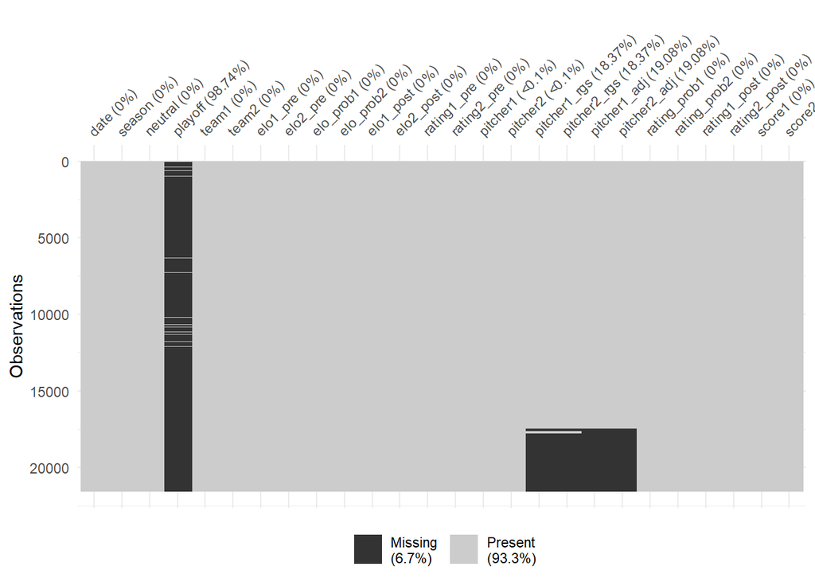

```r
vis_miss(dodger_elo)
```

Looks like the variables `playoff` and some pitcher variables are missing in the data set. Seeing how 98% of `playoff` is missing, it would be safe to get rid of that variable before we fit the data. As for the rest of the missing data, all of the observations in the pitcher variables are at the end of the data set. Since the data is ordered chronologically (as seen with the most recent games being shown in the `head` function), we can focus on the more recent observations. I think that the games from more recent years will have more influence on predicting win chances, since players, coaches, and even the game have all changed since the beginning.

```r
tail(dodger_elo)
```

```
## # A tibble: 6 × 26
##   date       season neutral playoff team1 team2 elo1_pre elo2_…¹ elo_p…² elo_p…³
##   <date>      <dbl>   <dbl> <chr>   <chr> <chr>    <dbl>   <dbl>   <dbl>   <dbl>
## 1 1884-05-10   1884       0 <NA>    PIT   LAD      1429.   1449.   0.505   0.495
## 2 1884-05-09   1884       0 <NA>    PIT   LAD      1426.   1452.   0.496   0.504
## 3 1884-05-05   1884       0 <NA>    LAD   WS7      1449.   1451.   0.531   0.469
## 4 1884-05-03   1884       0 <NA>    WS7   LAD      1453.   1447.   0.542   0.458
## 5 1884-05-02   1884       0 <NA>    WS7   LAD      1454.   1446.   0.547   0.453
## 6 1884-05-01   1884       0 <NA>    WS7   LAD      1450    1450    0.534   0.466
## # … with 16 more variables: elo1_post <dbl>, elo2_post <dbl>,
## #   rating1_pre <dbl>, rating2_pre <dbl>, pitcher1 <chr>, pitcher2 <chr>,
## #   pitcher1_rgs <dbl>, pitcher2_rgs <dbl>, pitcher1_adj <dbl>,
## #   pitcher2_adj <dbl>, rating_prob1 <dbl>, rating_prob2 <dbl>,
## #   rating1_post <dbl>, rating2_post <dbl>, score1 <dbl>, score2 <dbl>, and
## #   abbreviated variable names ¹elo2_pre, ²elo_prob1, ³elo_prob2
```

From the `date` variable, we can see that the earliest game recorded is from 1884. It would be safe to say that we can discard many of the earlier years of baseball for the model. To simplify it for the model, we can use baseball games starting after 2000.

```r
dodgerRecent_elo <- dodger_elo %>%
  filter(season >= 2000)
head(dodgerRecent_elo)
```

```
## # A tibble: 6 × 26
##   date       season neutral playoff team1 team2 elo1_pre elo2_…¹ elo_p…² elo_p…³
##   <date>      <dbl>   <dbl> <chr>   <chr> <chr>    <dbl>   <dbl>   <dbl>   <dbl>
## 1 2022-10-15   2022       0 d       SDP   LAD      1535.   1605.   0.412   0.588
## 2 2022-10-14   2022       0 d       SDP   LAD      1532.   1608.   0.401   0.599
## 3 2022-10-12   2022       0 d       LAD   SDP      1612.   1527.   0.698   0.302
## 4 2022-10-11   2022       0 d       LAD   SDP      1611.   1529.   0.693   0.307
## 5 2022-10-05   2022       0 <NA>    LAD   COL      1610.   1456.   0.735   0.265
## 6 2022-10-04   2022       0 <NA>    LAD   COL      1614.   1452.   0.744   0.256
## # … with 16 more variables: elo1_post <dbl>, elo2_post <dbl>,
## #   rating1_pre <dbl>, rating2_pre <dbl>, pitcher1 <chr>, pitcher2 <chr>,
## #   pitcher1_rgs <dbl>, pitcher2_rgs <dbl>, pitcher1_adj <dbl>,
## #   pitcher2_adj <dbl>, rating_prob1 <dbl>, rating_prob2 <dbl>,
## #   rating1_post <dbl>, rating2_post <dbl>, score1 <dbl>, score2 <dbl>, and
## #   abbreviated variable names ¹elo2_pre, ²elo_prob1, ³elo_prob2
```

```r
tail(dodgerRecent_elo)
```

```
## # A tibble: 6 × 26
##   date       season neutral playoff team1 team2 elo1_pre elo2_…¹ elo_p…² elo_p…³
##   <date>      <dbl>   <dbl> <chr>   <chr> <chr>    <dbl>   <dbl>   <dbl>   <dbl>
## 1 2000-04-08   2000       0 <NA>    NYM   LAD      1539.   1506.   0.582   0.418
## 2 2000-04-07   2000       0 <NA>    NYM   LAD      1538.   1507.   0.579   0.421
## 3 2000-04-06   2000       0 <NA>    WSN   LAD      1471.   1511.   0.477   0.523
## 4 2000-04-05   2000       0 <NA>    WSN   LAD      1470.   1513.   0.473   0.527
## 5 2000-04-04   2000       0 <NA>    WSN   LAD      1473.   1510.   0.482   0.518
## 6 2000-04-03   2000       0 <NA>    WSN   LAD      1476.   1506.   0.491   0.509
## # … with 16 more variables: elo1_post <dbl>, elo2_post <dbl>,
## #   rating1_pre <dbl>, rating2_pre <dbl>, pitcher1 <chr>, pitcher2 <chr>,
## #   pitcher1_rgs <dbl>, pitcher2_rgs <dbl>, pitcher1_adj <dbl>,
## #   pitcher2_adj <dbl>, rating_prob1 <dbl>, rating_prob2 <dbl>,
## #   rating1_post <dbl>, rating2_post <dbl>, score1 <dbl>, score2 <dbl>, and
## #   abbreviated variable names ¹elo2_pre, ²elo_prob1, ³elo_prob2
```

```r
dim(dodgerRecent_elo)
```

```
## [1] 3747   26
```

It looks like everything is in order. Now there are only 3747 observations in the data set.

### Adding more variables

```r
dodger_wl <- dodgerRecent_elo %>%
  mutate(dodger_result = case_when(team1 == 'LAD' & score1 > score2 |
                                   team2 == 'LAD' & score2 > score1 ~ 0,
                                   team1 == 'LAD' & score2 > score1 |
                                   team2 == 'LAD' & score1 > score2~ 1))
```

This code created our response variable, `dodger_result`, which is 0 if the Dodgers win, and 1 if they lose. I want to also simplify another variable, which is whether or not the Dodgers are at a home or away game. In this variable, 0 means that it’s a home game, and 1 means it’s an away game. Also, for ease of understanding, the Dodgers ELO rating and Pitcher Rolling game score will be put in their own columns as well

```r
dodger_wl <- dodger_wl %>%
  mutate(h_a = case_when(team1 == 'LAD' ~ 0,
                         team2 == 'LAD' ~ 1))
dodger_wl <- dodger_wl %>%
  mutate(dodger_rating = case_when(team1 == 'LAD' ~ rating1_pre,
                                   team2 == 'LAD' ~ rating2_pre))
dodger_wl <- dodger_wl %>%
  mutate(dodger_pitcher = case_when(team1 == 'LAD' ~ pitcher1_rgs,
                                    team2 == 'LAD' ~ pitcher2_rgs))
```

Now with the addition of these four variables, lets check again for any missing data.

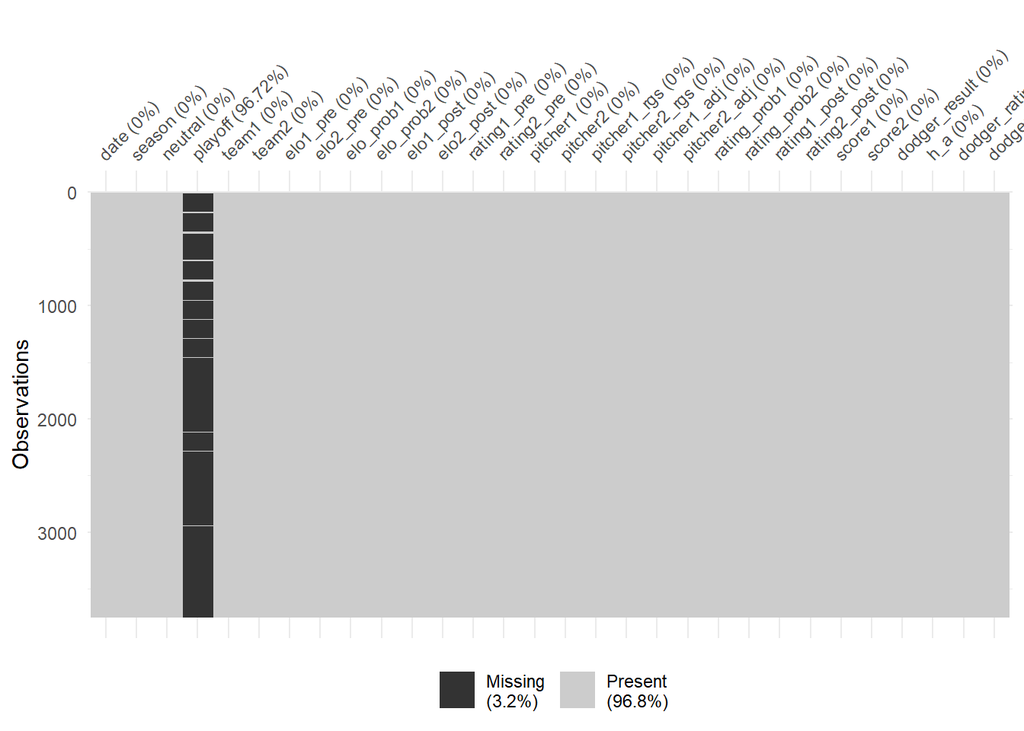

```r
vis_miss(dodger_wl)
```

- `season` - Year of season
- `neutral` - If the game was on a neutral site
- `team1` - Home team
- `team2` - Away team
- `elo_prob1` - Home team probability of winning according to ELO rating
- `elo_prob2` - Away team probability of winning according to ELO rating
- `rating1_pre` - Home team ELO rating
- `rating2_pre` - Away team ELO rating
- `pitcher1_adj` - Home starting pitcher’s adjustment to their team’s rating
- `pitcher2_adj` - Away starting pitcher’s adjustment to their team’s rating
- `rating_prob1` - Home team’s win probability with team ratings and starting pitchers
- `rating_prob2` - Away team’s win probability with team ratings and starting pitchers
- `h_a` - Whether it is a home or away game for the Dodgers
- `dodger_rating` - Dodgers ELO rating
- `dodger_pitcher` - Dodgers Pitcher’s rolling game score

At this point, it might be a little confusing on what exactly the ELO ratings mean. Basically, it was a rating system used by the website I received the data from, fivethirtyeight.com. It is like a mini prediction system itself, ranking based off of things like home-field advantage, travel, rest, starting pitchers, and more. I want to also see in this project if this ELO based system reflects the ability of the team as well. More information about fivethirtyeight’s ELO rating can be found [here](https://fivethirtyeight.com/features/how-our-mlb-predictions-work/).

### Cleaning our data set

```r
dodger_data <- dodger_wl %>%
  select(season, neutral, team1, team2, elo_prob1, elo_prob2,
         pitcher1_adj, pitcher2_adj, rating1_pre, rating2_pre, rating_prob1, rating_prob2,
         dodger_result, h_a, dodger_rating, dodger_pitcher)
dim(dodger_data) #Check how many variables there are
```

```
## [1] 3747   16
```

So now, the data set only has 16 variables, which is 15 predictor variables plus the response variable `dodger_result` . Now we can convert some of the variables to factors:

```r
dodger_data$season <- as.factor(dodger_data$season)
dodger_data$neutral <- as.factor(dodger_data$neutral)
dodger_data$team1 <- as.factor(dodger_data$team1)
dodger_data$team2 <- as.factor(dodger_data$team2)
dodger_data$dodger_result <- as.factor(dodger_data$dodger_result)
dodger_data$h_a <- as.factor(dodger_data$h_a)

#Assigned all variables to be a factor type
```

### EDA Visuals

Now that the data is ready, we can make some plots to see the relationship between all of the variables in the data set.

### Correlation Plot

Let’s see how a correlation plot heat map to see the general relationship of variables.

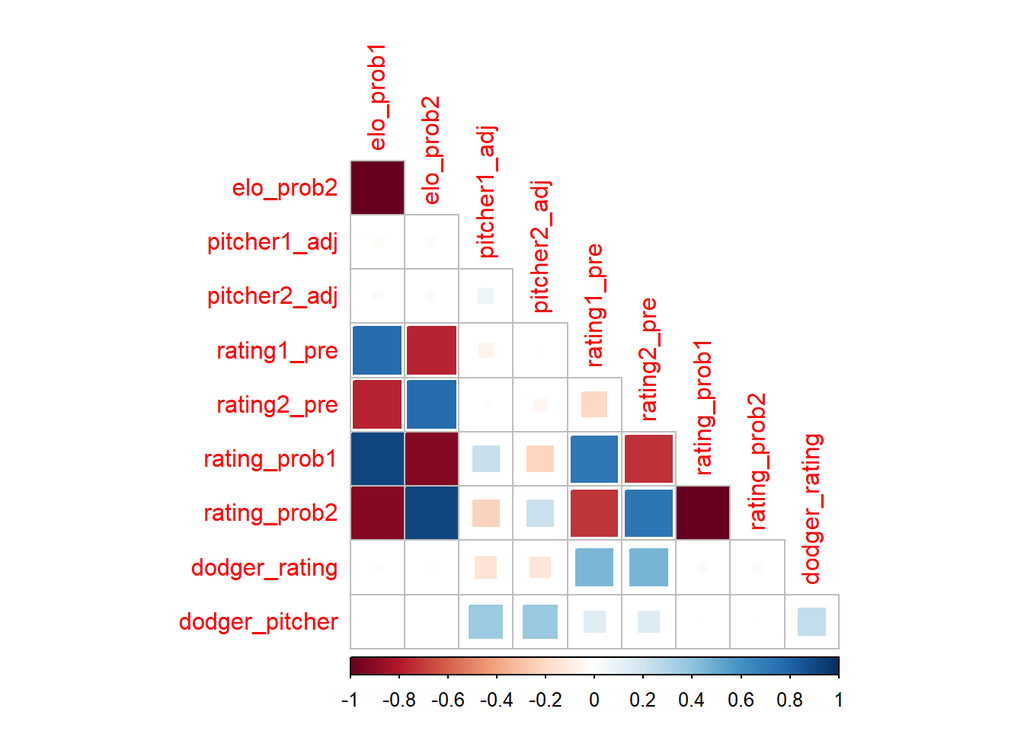

```r
#Correlation Matrix
dodger_data %>%
  select(where(is.numeric)) %>%
  cor() %>%
  corrplot(type = 'lower', diag = FALSE, method = 'square')
```

### Season

Let’s the the Dodger’s game result history through the years. We can do this by making a bar plot showing the number of wins and losses each year. For ease of understanding, the blue bar shows wins while the red bar shows losses. Overall, we see that the total amount of games played is about the same for all the years, except for 2020, which is understandable considering the high quarantine measures that year. The ratio of wins and losses seems to be about 50:50 in the earlier years, while more recent years have more wins than losses.

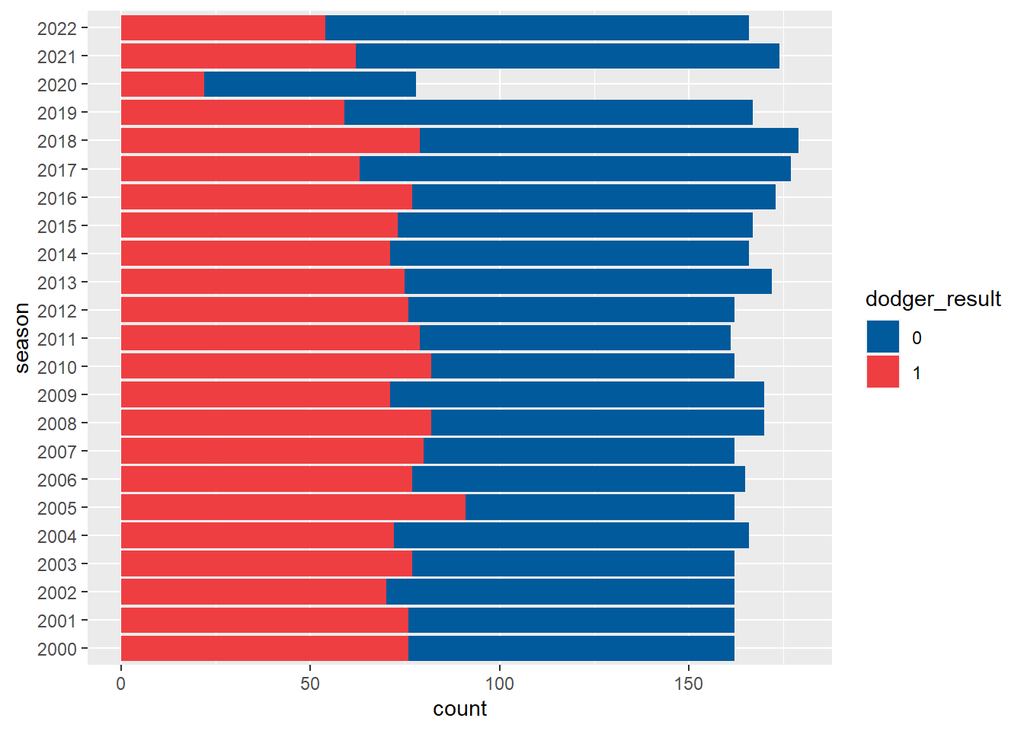

```r
ggplot(dodger_data, aes(y = season)) +
  geom_bar(aes(fill = dodger_result)) +
  scale_fill_manual(values = c('#005A9C','#EF3E42'))
```

### Home vs Away

Next, I want to plot the game history again, but this time comparing the home and away games’ win loss rate. 0 in the `h_a` variable is for home games, and 1 is for away games.

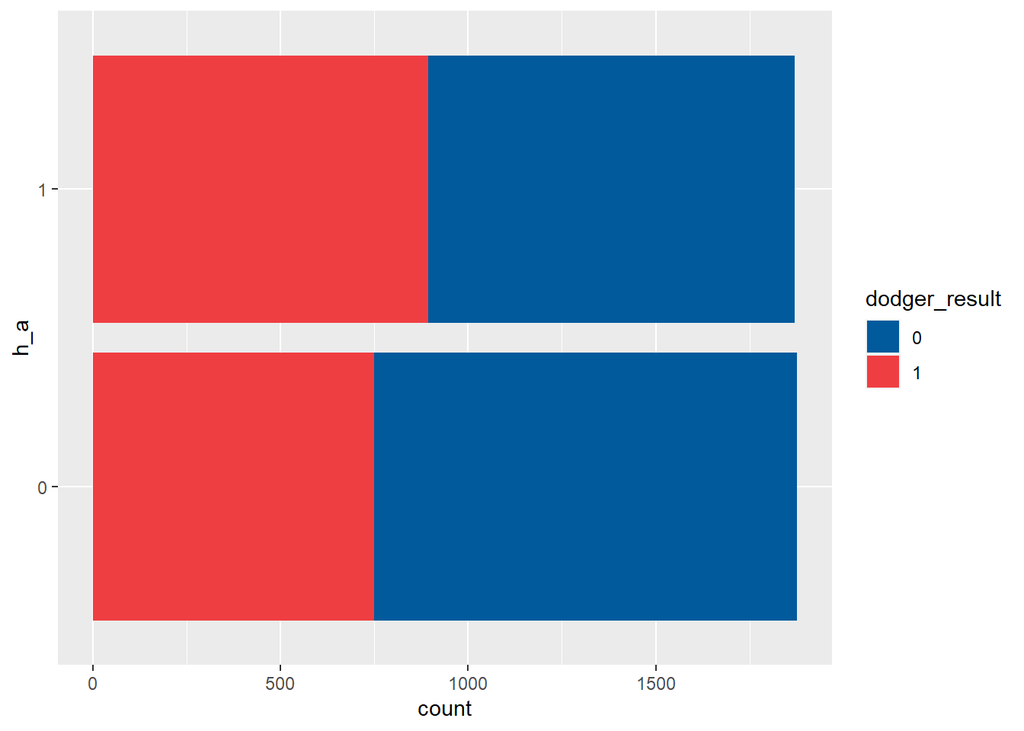

```r
ggplot(dodger_data, aes(y = h_a)) +
  geom_bar(aes(fill = dodger_result)) +
  scale_fill_manual(values = c('#005A9C','#EF3E42'))
```

### Games vs ELO Rating

To see if team rating really showed the strength of the team, here’s a graph. If a team’s ELO rating had a strong reflection of their strength, the graph would show more wins with a higher rating, and less wins with a lower rating.

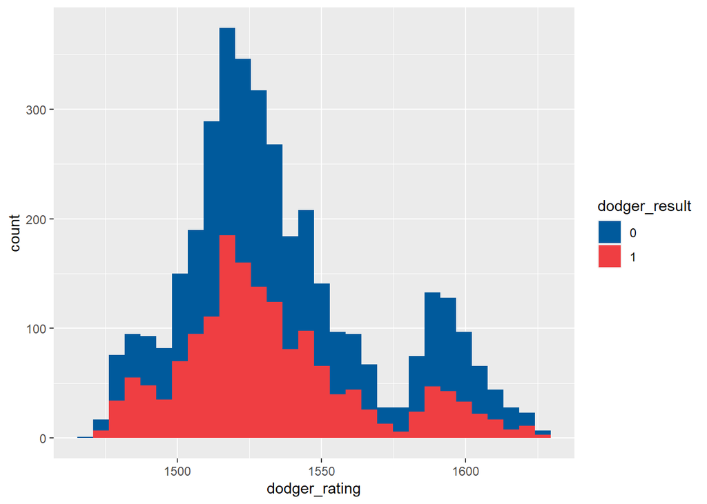

```r
 ggplot(dodger_data, aes(x = dodger_rating)) +
  geom_histogram(aes(fill = dodger_result)) +
  scale_fill_manual(values = c('#005A9C','#EF3E42'))
```

Looking at the graph, it looks like what I thought was generally true. The left end of the graph has more bars that have less blue compared to the bars on the right. Basically, for each bar, there is a bigger blue to red ratio as you go to the right. This means that as the Dodger’s ELO rating goes higher, they will have more wins.

## Model setup

```r
#setting the seed
set.seed(7452)
dodger_split <- dodger_data %>%
  initial_split(prop = 0.8, strata = 'dodger_result') #split the data

dodger_train <- training(dodger_split) #training set
dodger_test <- testing(dodger_split) #testing set
```

Lets check if the split was correctly 80/20

```r
dim(dodger_train)
```

```
## [1] 2997   16
```

```r
dim(dodger_test)
```

```
## [1] 750  16
```

2997 observations out of 3747 total is about 0.80 percent of the data. 750 observations out of 3747 is about 0.20 percent of the data. Those are the correct proportion, and are still an adequate amount for building a model.

### Building a recipe

Now, a recipe is needed for all of the models we are using. Since we are using the same data set for all of the models, we only need to make one recipe. The recipe is like a guide that all of the models follow. In basic terms, it tells the model, ‘this is what you are trying to predict, and you use all of these variables as the predictors’. Each model will use the predictors in different ways, but they will all follow the general rules. Also, we will dummy code all of our variables that we turned into factors. This will let us use categorical data in this model.

```r
dodger_recipe <- recipe(dodger_result ~ season + neutral + team1 + team2 + elo_prob1 + elo_prob2 + pitcher1_adj + pitcher2_adj + rating1_pre + rating2_pre + rating_prob1 + rating_prob2 + h_a + dodger_rating + dodger_pitcher, data = dodger_train) %>% #Recipe to be used
  step_dummy(all_nominal_predictors()) %>%
  step_normalize(all_predictors()) #Standardize all predictors
```

### Cross Validation

Cross validation is used to protect the model from overfitting any data. In this case, it will split the training set into 10 ‘folds’, which are smaller, equally proportional testing sets. They are then stratified with the response variable `dodger_result`.

```r
dodger_folds <- vfold_cv(dodger_train, v = 10, strata = dodger_result)
#Cross validation with 10 folds
```

Lastly, to have the same information for every model, the training folds, recipe, and training set will be saved into a folder in the project directory.

```r
save(dodger_train, dodger_test, dodger_recipe, dodger_folds, file = 'model-data/model.rda')
```

## Building our Models

Load up our Recipe, training and testing sets, and folds

```r
load('/Users/alcal/Desktop/PSTAT131-Final/model-data/model.rda')
```

1. Set up the model type, engine, and mode
2. Set up a workflow and add the model
3. Fit the model and workflow to the training set

For some of the models we are fitting, there are a few extra steps between 2 and 3. It concerns tuning the model parameters. These are the extra steps: 2_1. Make a tuning grid with chosen parameters for tuning. 2_2. Tune the model with the parameters 2_3. Select the best model chosen out of all the tuning combinations

### Logistic Regression Setup

Logistic regression predicts between two different states, true or false. In this case, it’s either win or lose. Logistic regression tries fitting a curve to the predictor variables to try and predict the result of the game.

Here’s the code for setting up a logistic regression model:

```r
log_reg_model <- logistic_reg() %>% #Model Setup
  set_engine('glm') %>%
  set_mode('classification')

log_workflow <- workflow() %>% # Set up workflow
  add_recipe(dodger_recipe) %>%
  add_model(log_reg_model)
```

### Linear Discriminant Analysis Model Setup

Linear Discriminant analysis takes the known categories of the variables, and tries to best separate each observation to the response variable. In this case, it reduces all of the predictor variables into one line, where it can maximize the distance between means. In this case, it wants to maximize the distance between the mean wins and mean losses.

```r
control <- control_resamples(save_pred = TRUE)
lda_model <- discrim_linear() %>%
   set_mode('classification') %>%
   set_engine('MASS')


lda_workflow <- workflow() %>%
  add_recipe(dodger_recipe) %>%
  add_model(lda_model)
```

### Elastic Net Model (Lasso) Setup

Lasso regression uses what is called variable selection and regularization to improve it’s prediction accuracy. Regularization means that the model is choosing which variables affect the model the most, and dropping those that have comparatively little effect.

```r
elastic_net_spec <- multinom_reg(penalty = tune(),
                                 mixture = tune()) %>%
  set_mode('classification') %>%
  set_engine('glmnet')

en_workflow <- workflow() %>%
  add_recipe(dodger_recipe) %>%
  add_model(elastic_net_spec)

en_grid <- grid_regular(penalty(range = c(-5,5)),
                        mixture(range = c(0,1)), levels = 10)
```

### K Nearest Neighbors Model Setup

For K nearest neighbors models, it is pretty simple. It predicts if a certain point of data will be classified a win or lose depending on which group of data points it is nearest to. Like the name says, the model looks for the ‘nearest neighbors’ to the data and classifies them accordingly.

```r
knn_model <- nearest_neighbor(
      neighbors = tune(),
      mode = 'classification') %>%
  set_engine('kknn')

knn_workflow <- workflow() %>%
  add_recipe(dodger_recipe) %>%
  add_model(knn_model)

#Set up tuning parameters
knn_tune <- parameters(knn_model)
#Set up grid
knn_grid <- grid_regular(knn_tune, levels = 2)
```

### Random Forest Model Setup

Random forest models use a tree based system to classify the observations. The ‘forest’ is made with random subsets of the data set. These subsets then create an output. As these outputs are made, a majority decision classifies the trees as what was the majority output. In this projects terms, it’s as if a number of samples were chosen from the testing set, which creates a decision tree and determines the class of the tree as ‘win’ or ‘lose’. The final output of the random tree will be shown as whatever the majority class was chosen. So if the majority were ‘win’, the final output would be ‘win’.

```r
rf_model <- rand_forest(min_n = tune(),
                        mtry = tune(),
                        mode = 'classification') %>%
  set_engine('ranger')

rf_workflow <- workflow() %>%
  add_recipe(dodger_recipe) %>%
  add_model(rf_model)

rf_tune <- parameters(rf_model) %>%
  update(mtry = mtry(range= c(2,92))) #Set up tuning parameters
#Set up grid
rf_grid <- grid_regular(rf_tune, levels = 2)
```

We will save the setup for later

```r
save(rf_model, rf_workflow, rf_tune, file = 'model-data/rf-setup.rda')
```

### Fitting Models

#### Logistic Regression Fitting

```r
log_fit <- fit_resamples(log_workflow, dodger_folds)
```

```r
save(log_fit, file = 'model-data/log-fit.rda')
```

#### Linear Discriminant Analysis Fitting

```r
lda_fit <- fit_resamples(resamples = dodger_folds,
                         lda_workflow)
```

```r
save(lda_fit, file = 'model-data/lda-fit.rda')
```

#### Lasso Model Fitting

To fit tuned models, the function `tune_grid()` is used.

```r
tune_res <- tune_grid(
  en_workflow,
  resamples = dodger_folds,
  grid = en_grid
)
```

```r
save(tune_res, file = 'model-data/tune-res.rda')
```

#### K Nearest Neighbors Model Fitting

Once the parameters are set up, we fit the model.

```r
knn_res <- knn_workflow %>%
  tune_grid(resamples = dodger_folds,
            grid = knn_grid)
```

```r
save(knn_res, knn_grid,knn_tune, file = 'model-data/knn-res.rda')
```

### Random Forest Model Fitting

```r
rf_res <- rf_workflow %>%
  tune_grid(
    resamples = dodger_folds,
    grid = rf_grid)
```

```r
save(rf_res, rf_grid, rf_tune, file = 'model-data/rf-res.rda')
```

## Model Results

When we look at the results of the models, we want to take note of the `roc_auc` value in each of the results. The higher the number, the better the model is at predicting the result of a game. Lets start by loading in all of the fitted models. These take a lot of time to run, so they have been previously prepared so that they are not run every time this project is saved.

```r
load('/Users/alcal/Desktop/PSTAT131-Final/model-data/log-fit.rda')
load('/Users/alcal/Desktop/PSTAT131-Final/model-data/lda-fit.rda')
load('/Users/alcal/Desktop/PSTAT131-Final/model-data/tune-res.rda')
load('/Users/alcal/Desktop/PSTAT131-Final/model-data/knn-res.rda')
load('/Users/alcal/Desktop/PSTAT131-Final/model-data/rf-res.rda')
```

### Logistic Regression

```r
log_metrics<- collect_metrics(log_fit)
log_metrics
```

```
## # A tibble: 2 × 6
##   .metric  .estimator  mean     n std_err .config
##   <chr>    <chr>      <dbl> <int>   <dbl> <chr>
## 1 accuracy binary     0.576    10 0.00719 Preprocessor1_Model1
## 2 roc_auc  binary     0.581    10 0.00756 Preprocessor1_Model1
```

For Logistic regression, the `roc_auc` turned out to be 0.5813. Basically, after being trained on the training set, this model predicts the result of a game correctly about 58% of the time.

### Linear Discriminant Analysis

```r
lda_metrics <- collect_metrics(lda_fit)
lda_metrics
```

```
## # A tibble: 2 × 6
##   .metric  .estimator  mean     n std_err .config
##   <chr>    <chr>      <dbl> <int>   <dbl> <chr>
## 1 accuracy binary     0.576    10 0.00759 Preprocessor1_Model1
## 2 roc_auc  binary     0.582    10 0.00758 Preprocessor1_Model1
```

For LDA, the `roc_auc` is 0.5818. This value is very similar to logistic regression, but this one is better by about 5 hundredths of a percent, so about the same here.

### Plot for Elastic Net (Lasso)

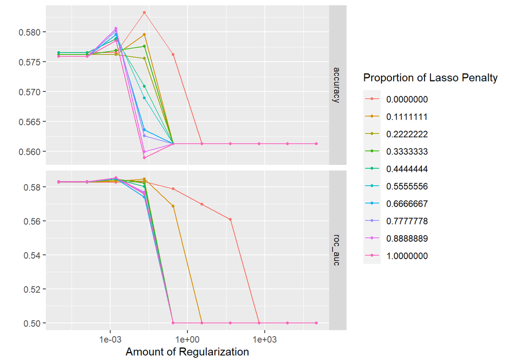

```r
autoplot(tune_res)
```

In this graph, we can see each ten different colored lines on two graphs, each line represents a different lasso penalty value chosen. In general, it looks like lower penalty values lead to higher `roc_auc` on the second graph. Lets see what model combination is the best

```r
best_fit_en <- show_best(tune_res, metric = 'roc_auc') %>%
  select(-.estimator, .config) %>%
  slice(1)
best_fit_en
```

```
## # A tibble: 1 × 7
##   penalty mixture .metric  mean     n std_err .config
##     <dbl>   <dbl> <chr>   <dbl> <int>   <dbl> <chr>
## 1 0.00167       1 roc_auc 0.585    10 0.00810 Preprocessor1_Model093
```

From the `.config` column, it seems that model number 93 is the best performing. It has an `roc_auc` value of 0.5852, which is the highest number so far. However, it’s still very close to Logistic Regression and LDA.

### Plot for KNN

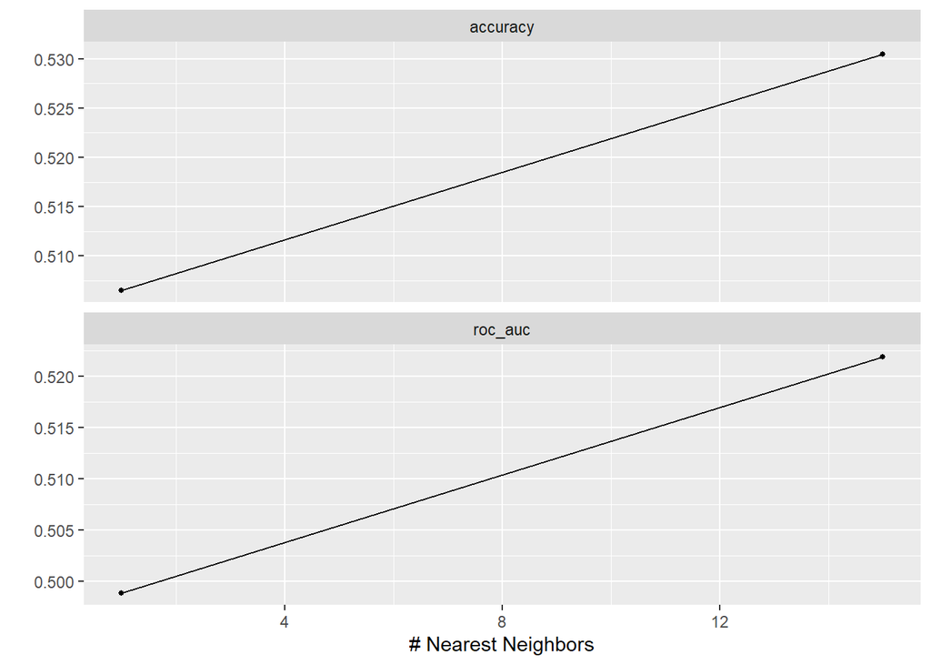

```r
autoplot(knn_res)
```

This graph’s best `roc_auc` is at around 0.52, which is the lowest number yet. Here is the best fitting model:

```r
best_fit_knn <- show_best(knn_res, metric = 'roc_auc') %>%
  select(-.estimator, .config) %>%
  slice(1)
best_fit_knn
```

```
## # A tibble: 1 × 6
##   neighbors .metric  mean     n std_err .config
##       <int> <chr>   <dbl> <int>   <dbl> <chr>
## 1        15 roc_auc 0.522    10 0.00914 Preprocessor1_Model2
```

It looks like K nearest numbers is the worst performing one so far. With an `roc_auc` of about 0.5219, it is around 6 percentage points behind the rest. However, it is not so far behind that it is completely lost in predicting the game result.

### Plot for Random forest

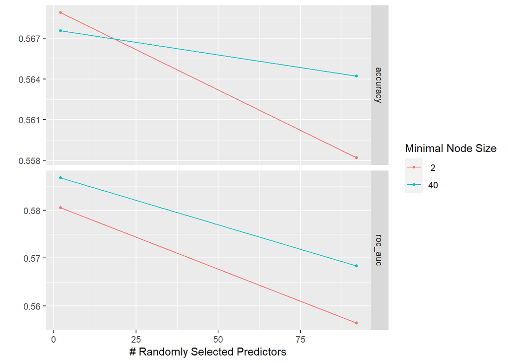

```r
autoplot(rf_res)
```

What’s the best random forest model?

```r
best_fit_forest <- show_best(rf_res, metric = 'roc_auc') %>%
  select(-.estimator, .config) %>%
  slice(1)
best_fit_forest
```

```
## # A tibble: 1 × 7
##    mtry min_n .metric  mean     n std_err .config
##   <int> <int> <chr>   <dbl> <int>   <dbl> <chr>
## 1     2    40 roc_auc 0.587    10 0.00770 Preprocessor1_Model3
```

It looks like random tree model 3 was the best performing, with an ROC AUC of 0.5867, the highest number yet.

### Summary of all ROC_AUC

I wanted to get a graph that quickly showed all of the different `roc_auc` between models. This should give a clear idea as to what model works the best, and which performs the worst.

```r
log_auc <- log_metrics$mean
log_auc <- log_auc[2]
lda_auc <- lda_metrics$mean
lda_auc <- lda_auc[2]
tune_auc <-best_fit_en$mean
knn_auc <-best_fit_knn$mean
rf_auc <-best_fit_forest$mean
Model <- c('log_reg','lda','lasso','knn','random_forest')
auc <- c(log_auc,lda_auc,tune_auc,knn_auc,rf_auc)
```

Bar plot of the data:

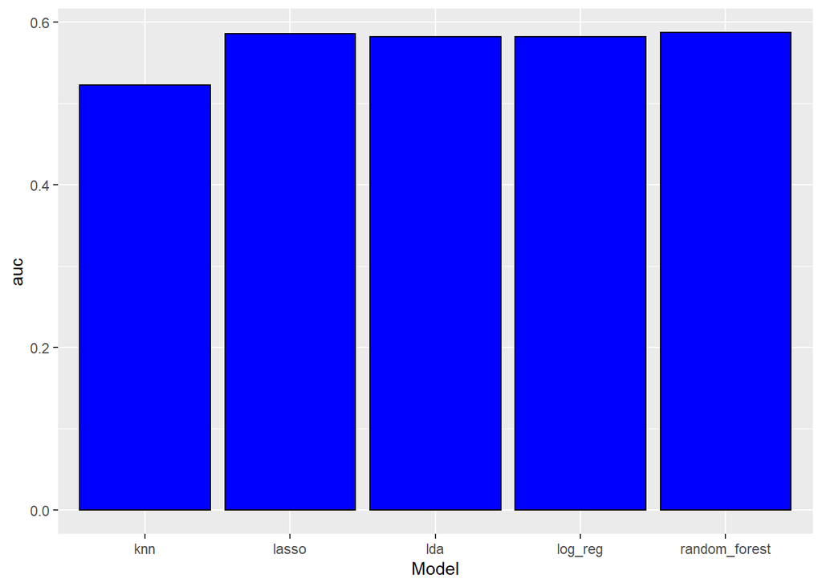

```r
all_auc <- data.frame(Model,auc)
ggplot(all_auc, aes(x = Model, y = auc)) +
  geom_bar(stat = 'identity', color ='black', fill = 'blue')
```

Dot plot of `roc_auc`

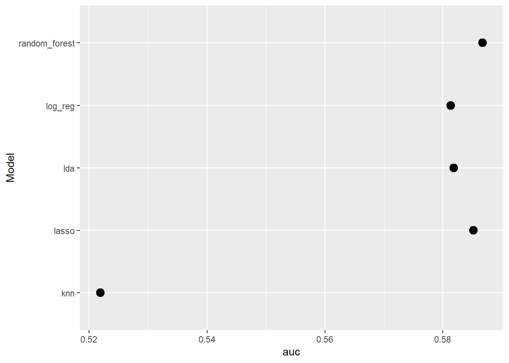

```r
ggplot(all_auc, aes(x=auc, y=Model)) +
  geom_dotplot(binaxis = 'y',stackdir = 'center')
```

From these graphs, it is evident that random forest has the best chances of predicting the result of a baseball game for the Dodgers.

## Building the Final Model

Now that we know our best model, we can create one last workflow that is tuned to the best parameters in the random forest.

```r
load('/Users/alcal/Desktop/PSTAT131-Final/model-data/rf-setup.rda')

rf_workflow_final <- rf_workflow %>%
  finalize_workflow(select_best(rf_res, metric = 'roc_auc'))
```

Now there’s only the final fit to make the model

```r
rf_final_fit <- fit(rf_workflow_final, data = dodger_train)
```

### Testing the Test Set

Now we can finally see how our chosen best model predicts data from the testing set.

```r
predictions <- augment(rf_final_fit, new_data = dodger_test) %>%
  select(dodger_result, starts_with('.pred'))
predictions
```

```
## # A tibble: 750 × 4
##    dodger_result .pred_class .pred_0 .pred_1
##    <fct>         <fct>         <dbl>   <dbl>
##  1 1             0             0.611   0.389
##  2 0             0             0.640   0.360
##  3 1             0             0.609   0.391
##  4 0             0             0.632   0.368
##  5 1             0             0.687   0.313
##  6 0             0             0.643   0.357
##  7 0             0             0.686   0.314
##  8 0             0             0.552   0.448
##  9 0             0             0.539   0.461
## 10 0             0             0.609   0.391
## # … with 740 more rows
```

Before we see the overall ROC AUC on the testing set, lets check out the plot for `roc_auc`. A plot of `roc_auc` should look like an upside down L. The more it looks like a right angle, the better the model is at predicting the response variable. Basically, we want it to look more and more like the field at Dodger Stadium.

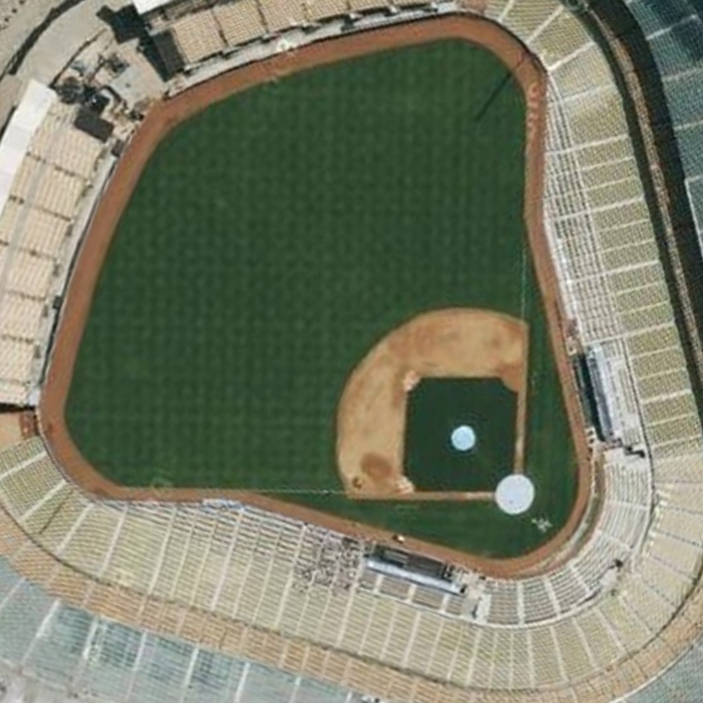

Birds Eye View of Dodger Stadium. Take note of the shape of the bases

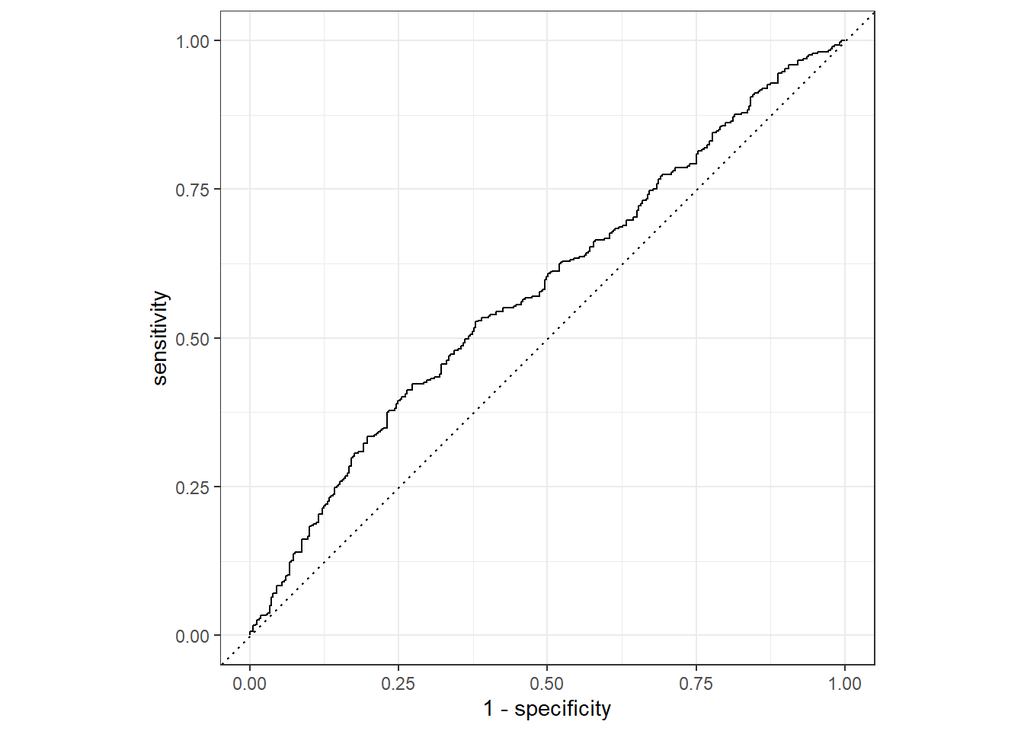

```r
dodger_roc_plot <- augment(rf_final_fit, new_data = dodger_test) %>%
  roc_curve(dodger_result, estimate = .pred_0)
autoplot(dodger_roc_plot)
```

From the looks of the graph, it doesn’t look like it predicts very well. Instead of something similar to an upside down L, it looks more like a slanted longbow. However, that was to be expected. None of the models that were fitted went above 60% accuracy, and the best training set had `roc_auc` at around 58%. To compare, a prediction rate of exactly 50% would look like a diagonal line, where the dotted line on the graph is. Let’s see what the actual `roc_auc` value is.

```r
final_roc_auc <- augment(rf_final_fit, new_data = dodger_test) %>%
  roc_auc(dodger_result, estimate = .pred_0) %>%
  select(.estimate)

final_roc_auc
```

```
## # A tibble: 1 × 1
##   .estimate
##       <dbl>
## 1     0.581
```

## Conclusion

With lots of data analysis, testing, and research, it turns out that Random Forest models are the best at predicting if the Dodgers will win a game. However, it was nowhere near perfect.

After making the model, It seems that with the data provided, it is difficult to predict the result of a baseball game. One more thing I wanted to look at was the confusion matrix of the results.

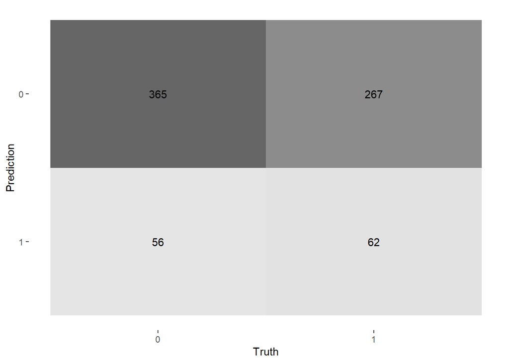

```r
predictions %>%
  conf_mat(truth = dodger_result, estimate = .pred_class) %>%
  autoplot(type = "heatmap")
```

How could we explain the predictions the model chose? It would seem like the model liked to default to wins typically. If it chose one of the options most of the time, it would still be about 50% right considering the graphs in the EDA. Perhaps it was also that none of the factors gave very significant indication of a win or loss, so the model was only influenced very little by the predictor variables.

If I could research this project more, I would want to check every match up the Dodgers have. They could be much better facing a certain team, which can be a good indicator of a win or loss. However, with 29 other teams, I can only imagine how long some of the models may take.

Another thing I would have liked to try was checking the influence of the pitchers by name. Since the pitcher names are a character variable, with tons and tons of different names, it was difficult to implement into the models. So instead, I opted to only use the rolling game score and adjustment of the pitchers.

Ultimately though, I think this result is difficult to predict. You never know what can happen at a baseball game, and this is proof of that. If anything, this model gives an indication on how a baseball game will go slightly better than a coin flip, given that it is right only about 58% of the time. This project was a great opportunity to try my hand at machine learning, and not only grow my understanding of programming, but for bonding with my family, especially my dad, by learning all about baseball.